# Part II - Diapositives sur l'analyse des Prêts ProsperLoanData

## Par Jean-Philippe ONDO

## Aperçu de l'enquête

> Nous avons explorer un ensemble de données contenant 113 937 prêts avec 81 variables sur chaque prêt, y compris le montant du prêt, le taux de l'emprunteur (ou taux d'intérêt), le statut actuel du prêt, le revenu de l'emprunteur et bien d'autres choisi parmit la liste suivant [site](https://docs.google.com/document/d/e/2PACX-1vQmkX4iOT6Rcrin42vslquX2_wQCjIa_hbwD0xmxrERPSOJYDtpNc_3wwK_p9_KpOsfA6QVyEHdxxq7/pub) fournit par Udacity. Les attributs/variables du jeu de données sont expliqués dans le tableau dictionnaire de données Tout d'abord nous avons importer les différente bibliothéques ainsi que l'ensemble de données choisi. Puis son procéssus d'analyse a été structurer comme suite:
> - Evaluation visuel
> - Evaluation Programmatique
> - Observations
> - Nettoyages sur la base de définition du problémes, code et test
> - Explorations Univariés sur la base des questions visuel et observations
> - Explorations Bivariés sur la base des questions visuel et observations
> - Explorations Multivariés sur la base des questions visuel et observations
> - Conclusions sur l'ensemble des visuels

## Aperçu de l'ensemble de données

## Visualisation 1

> Il est à priorie nécéssaire de connaitre Quel "Duree" compte le plus grand nombre de prêts dans l'ensemble de données ? afin de voir sur quel période l'analyse est fondé et comment?

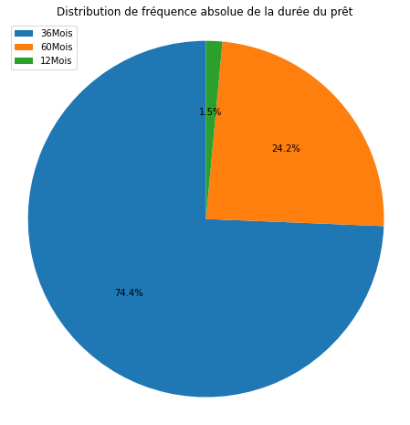

> D'après le graphique ci-dessus, nous pouvons voir que la majorité des personnes qui ont contracté des prêts ont opté pour le plan de 36 mois. Donc une proportion plus élevée de prêts ont été approuvés pour une période de 36 mois, tandis qu'une proportion moindre a été approuvée pour une période de 60 mois avec une très faible proportion de prêts approuvés pour une période de 12 mois.Ceci nous permet de voir déjà les délais viable de prêt pour être accepter.

## Visualisation 2

> Quelle relation ou modèle existe-t-il entre les variables numériques de l'ensemble de données favorisant le prêt ?

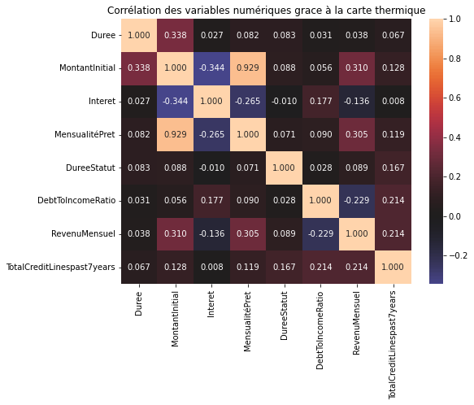

## Visualisation 3

> Examinons la relation entre Interet, LoanStatus et la Duree du Prêt ? afin de permettre une meilleur corrélation et apporter de bonne conclusion d'analyse

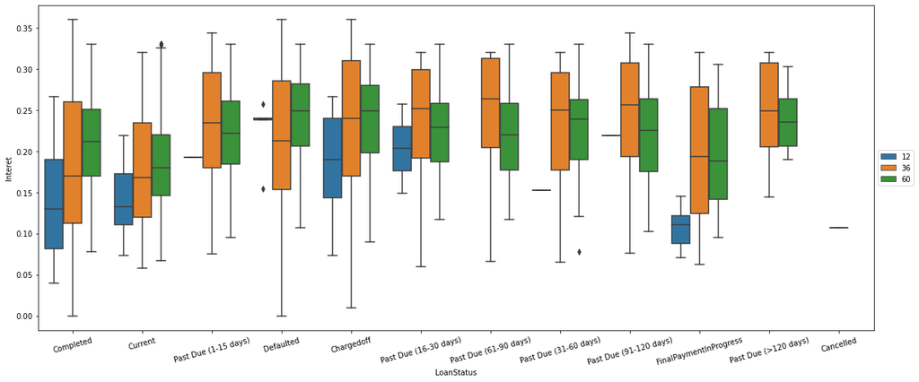